# Teknolojik Yenilik, Ücretler ve Gelir Dağılımı

Çiğdem Ekiz ve Erol Taymaz  
İktisat Bölümü  
Orta Doğu Teknik Üniversitesi  
http://users.metu.edu.tr/etaymaz

**EconAnadolu 2022**  
Eskişehir / 13-15 Mayıs 2022

# Niçin yenilik ve ücretler?

- Teknolojik yenilikler uzun dönemli ekonomik büyüme açısından belirleyici
  - Rekabet gücü ve yenilik rantı açısından da…
- Yenilik → ücret ilişkisi gelir dağılımı açısından önemli
  - Ücret/ücret dışı gelir eşitsizliği
  - Ücretliler arası eşitsizlik
  - Yeniliklerin teşvik edilmesi

# Yenilik ve ücretler

- Yenilik → yeni bilgi
  - Üretkenlik artışı
  - Zımni (tacit) bilgi artışı
  - Yenilik yeteneği artışı
- Yenilik → ücretler [$w = \theta lp + (1 - \theta) w^*$]
  - Üretkenlik artışı
    - Çalışanların pazarlık gücü varsa
  - Pazarlık gücünün artması
  - “Beşeri sermaye” artışı
- Bu etkiler tüm çalışanlar için aynı ölçüde geçerli değil!

# Yenilik ve ücretler

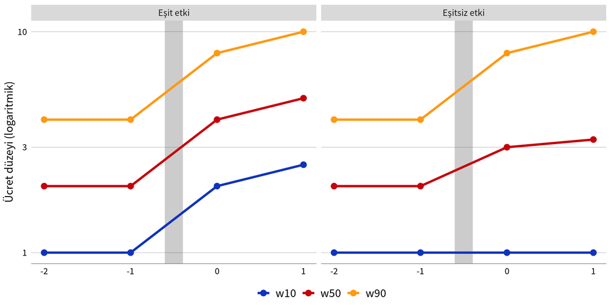

# Model

- Firmalar *t = 1, …, T* zamanında gözleniyor
  - Her firma her yıl gözleniyor
- İlk yenilik *q* zamanında yapılıyor
  - *t = 1, …, q-1* döneminde yenilik yapan yok
- Yeniliğin etkisi *q*’dan *T*’ye kadar devam ediyor
  - Aşamalı işlem modeli
  - $d_t$ (*t ≥ q*) *t* yılında yenilik yapan firma grubu (cohort)
  - $z_{it}$ yenilik kukla değişkeni

# Model

- *s* zamanında yapılan yeniliğin *t* zamanında ücrete etkisi

$te_t(s) = w_t(s) - w_t(∞), s = q, ..., T$

- Yenilik yapan üzerinde ortalama ücret etkisi (ATT)

$\tau_{st} = E[te_t(s) | d_s = 1], s = q, ..., T; t = s, ..., T$

# Model

- Varsayımlar
  - Öngörememe (etki başlangıcı)
    - $E[w_t(s) - w_t(∞) | d] = 0, t < s$
  - Paralel eğilim
    - $E[w_t(∞) - w_1(∞) | d_q, ..., d_T] = E[w_t(∞) - w_1(∞)], t = 2, ..., T$
- Beklenen ücret (*d*’ye bağlı)
  - $E(w_t | d) = E[w_t(∞) + d_q \tau_{qt} + ... + d_T \tau_{Tt}]$
- Beklenen ücret sabit etkiler modeli ile tahmin edilebilir (Wooldridge, 2021)
  - $w_{it} = f_i + T_t + \tau z_{it} + \beta X_{it} + \epsilon_{it}$
    - Etki pozitif olduğu halde, homojen etki olmaması durumunda negatif tahmin edilebilir
    - *X* endojen olabilir
  - $w_{it} = f_i + T_t + \tau_{st}z_{it} d_{is} T_t + T_t X_i \pi_t + \rho_{st}z_{it} d_{is} T_t \dot X _{ir}$
    - Bu modele $X_i$ eğilimi etkileyen değişkenler
    - Etki düzeyinin yenilik sonrası zamana bağlı olduğunu varsayıyoruz
    - $\tau_{st} = \tau_{t-s}, s = q, ..., T, t = s, ..., T$

# Veri kaynakları

- Sanayi Bakanlığı Girişimci Bilgi Sistemi
  - SGK verileri
    - Çalışan bazında 3 aylık/aylık veriler
  - Bilanço ve gelir tablosu
  - Patent başvurusu yapan firmalar
  - Ar-Ge yapan firmalar

# Ücretler

- Asgari ücret
  - 2022 Net 4253 TL, brüt 5004 TL, işgücü maliyeti 5880 TL
- Sosyal sigorta primi
  - Taban (asgari ücret)
  - Tavan (aylık brüt 37500 TL)
    - Tavan/taban oranı
    - 2017-2022: 7.5
    - 2009-2016: 6.5

# Firma seçimi

- İmalat sanayii
  - Bilanço esasına göre vergi veren
  - Belirli bir süreklilik gösteren
  - En az bir kişi istihdam eden
- 2007-2020 döneminde sürekli olarak faaliyet gösteren
  - **2009** sonrası patent başvurusu yapan
  - **2009** sonrası Ar-GE yapan
  - Kontrol grubu (CEM, kabalaştırılmış tam eşleme)
    - Eşleştirme değişkenleri: 2008 çalışan sayısı (log), firma yaşı (log), sermaye yoğunluğu (log), ihracat konumu, faaliyet gösterdiği sektör (NACE Rev2, 2-hane düzeyinde)

# Firma sayıları, 2020

- Tüm firmalar: 459600
  - Bilançosu olan: 216503
  - **Süreklilik gösteren: 156646**
    - En az 1 çalışanı olan: 135113
    - Patent: 851
    - AR-GE: 3022
- **Her yıl faaliyet gösteren: 32274**
  - Patent: 429
  - AR-GE: 1470
- **2009-2020’de patent alanlar: 1095 (Kontrol grubu 1095)**
- **2009-2020’de Ar-Ge yapanlar: 2010 (Kontrol grubu 2010)**

# Ortalama firma büyüklüğü

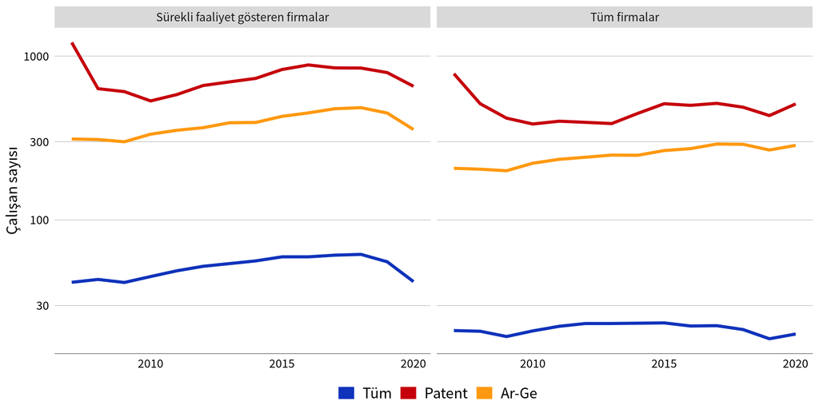

# Ortalama firma büyüklüğü

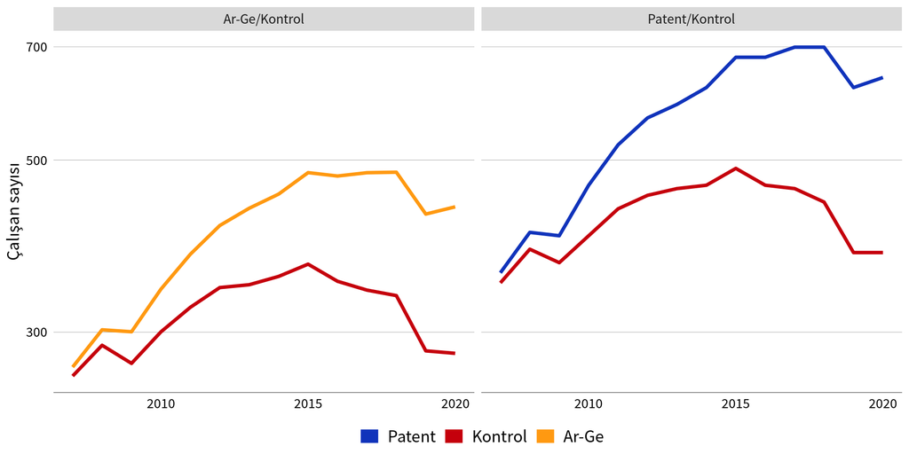

# Ortanca ücretler

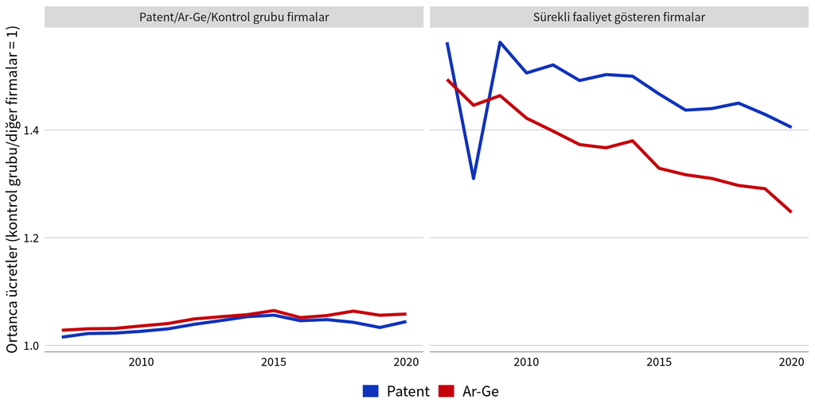

# Firma içi ücret farklılıkları

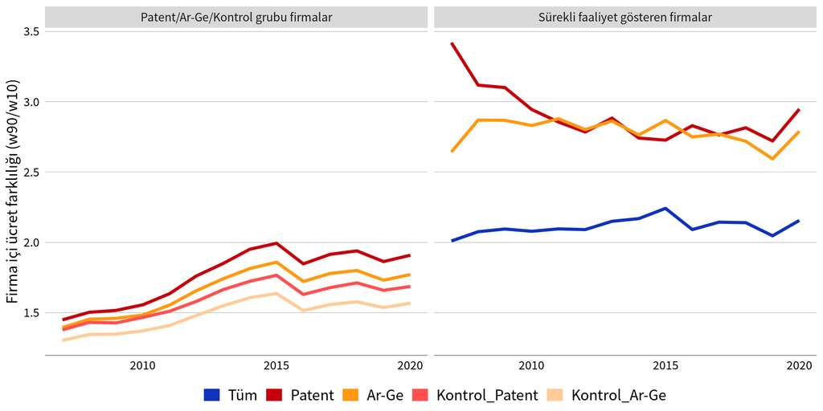

# Tahmin sonuçları

- Yöntem: DID/Sabit etkiler modeli - Wooldridge (2021)
- Karşılaştırmalar
  - Kontrol grubu (CEM)
  - Tüm firmalar
- Etki başlangıcı: 3 yıl
- Yazılım: *R fixest* paketi

# Patentlerin ücret etkisi

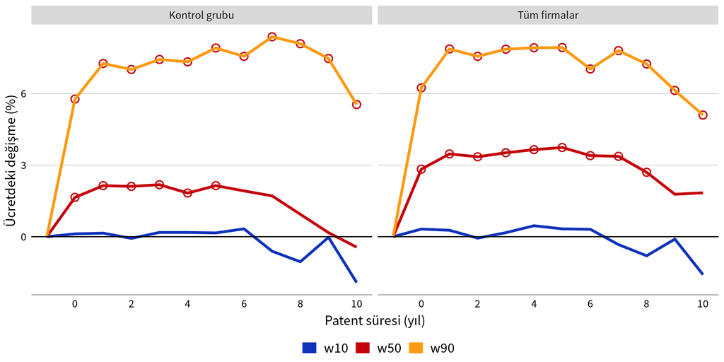

# Ar-Ge’nin ücret etkisi

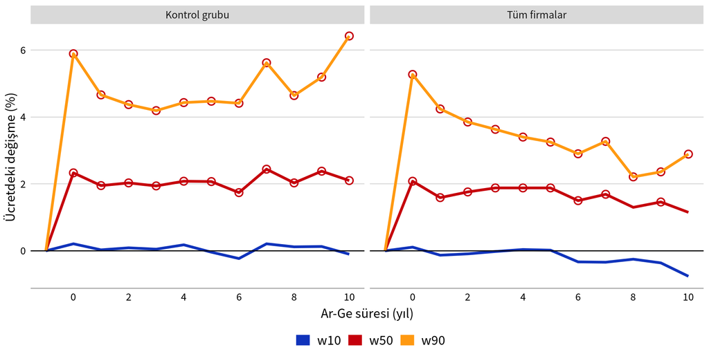

# Patent ve Ar-Ge’nin üretkenlik etkisi

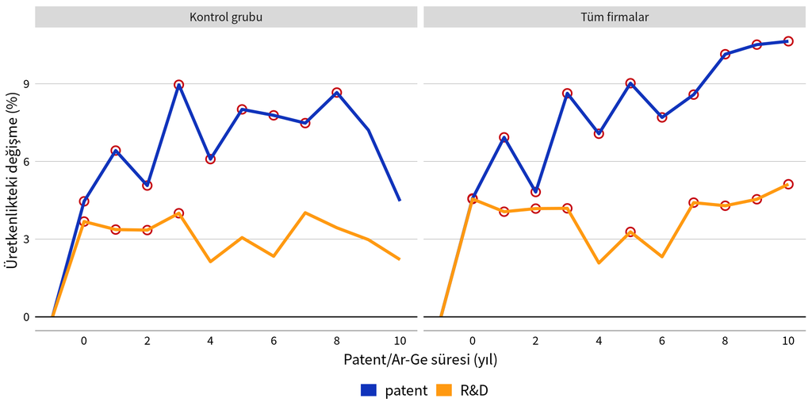

# Patent ve Ar-Ge’nin karlılık etkisi

[figure not shown]

# Sonuçlar

- Yenilikler ücret ve emek üretkenliğinde uzun dönemli artışa yol açıyor
  - Patent başvurularındaki etki Ar-Ge’den daha fazla
- Emek ve sermaye arasındaki gelir eşitsizli artıyor
- Asgari ücret kazananlar ile yüksek ücretliler arasındaki ücret eşitsizli artıyor
- İşgücü devir oranına etki yok
- Ayrılan ve işe yeni girenlerin ücretlerine etki yok

Teşekkürler…